# CombineTraC_SE-BQE

HT

2023-02-20

## Combine WFD TraC Supporting and Biological QE data

This script joins the previously extracted water quality data (WQ from WISE-6) for selected supporting elements (SE) to the biological classifications (BQE from WISE-4 & WISE-2), for both TRaC water categories (TW & CW).

- From WISE2, disaggregated EQR & EQS data by Year and Site was used except for EE, IE and SI for which only aggregated data by WB was available, so the later was also extracted; data for all years available until 2021.
- From WISE4, WB aggregated EQS data was available for the 1st nd 2nd reporting cycle years 2010 and 2016.

### 1. Create a list of determinand codes available per TraC water category

```r
#Create a list of determinand codes of interest
observedPropertyDeterminandCode <- c("EEA_3131-01-9","CAS_14797-55-8","EEA_3152-01-0","CAS_14797-65-0",
             "CAS_14798-03-9","CAS_14265-44-2","EEA_3132-01-2","EEA_3164-01-0",
             "EEA_3111-01-1","EEA_3141-01-3","EEA_31615-01-7","EEA_31-02-7",
             "CAS_7723-14-0","EEA_3133-05-9","EEA_3133-06-0","CAS_16887-00-6",
             "CAS_7664-41-7","EEA_3133-01-5","EEA_3112-01-4","EEA_3161-02-2",
             "EEA_31613-01-1","EEA_31-03-8","EEA_3161-05-5","EEA_3161-03-3")

observedPropertyDeterminandLabel <- c("Oxygen saturation","Nitrate","pH","Nitrite",
                                      "Ammonium","Phosphate","Dissolved oxygen",
                                      "Chlorophyll a","Secchi depth","Salinity",
                                      "Total nitrogen","Total suspended solids",
                                      "Total phosphorus","Dissolved organic carbon (DOC)",
                                      "Total organic carbon (TOC)","Chloride",
                                      "Ammonia","BOD5","Turbidity","Total oxidised nitrogen",
                                      "Non-ionised ammonia","Total dissolved solids",
                                      "Total inorganic nitrogen","Total organic nitrogen")
# add an abbreviated name for convenience
Det <- c("DOpc","NO3","pH","NO2","NH4","PO4P","DO","CHLA","SD","SAL","TN","SS","TP","DOC",
         "TOC","Cl","NH3","BOD5","TURB","TON","NH3UI","TDS","TIN","TON")

resultUom <- c("%","mg{NO3}/L","[pH]","mg{NO2}/L","mg{NH4}/L","mg{P}/L","mg/L",
               "ug/L","m","{PSU}","mg{N}/L", "mg/L","mg{P}/L","mg{C}/L","mg{C}/L",
               "mg/L","ug/L","mg{O2}/L","{NTU}","mg{N}/L","mg{NH3}/L","mg/L",
               "mg{N}/L","mg{N}/L")

# create data frame and rename columns
Determinands <- data.frame(observedPropertyDeterminandCode,observedPropertyDeterminandLabel,Det,resultUom)

#Save determinands used as rds file
saveRDS(Determinands,file = here("Data","Determinands_TRaC.rds")) #TRaC WQ sites
notes <- "Determinands extracted in extractWFDdata_WISE6_SE for TRaC waters."
writeLines(notes,here("Data","ReadMe_Determinands.txt"))

#Save determinands used as xlsx workbook
wb <- createWorkbook()
addWorksheet(wb,"dets")
addWorksheet(wb, "notes")
writeData(wb,"dets",Determinands,startRow = 1,startCol = 1)
writeData(wb,"notes",notes,startRow = 1,startCol = 1)
saveWorkbook(wb,file =here("Data","Determinands.xlsx"),overwrite = TRUE)
```

### 2. Import water quality data from the WISE6 for Supporting Elements available for TraC Waters

Data will be summarised at Water Body level considering the years (>2009 & <2016) leading to the 2nd reporting cycle 2016

```r
#import the SE WQ data for TRaC
WQdatTWSite <- readRDS(file = here("Data","dat_WQ_TW.rds")) #TW
WQdatCWSite <- readRDS(file = here("Data","dat_WQ_CW.rds")) #CW

#add Determinands short names in Det
Determinands.s<- Determinands %>% select(observedPropertyDeterminandLabel,Det)
WQdatTWSite <- WQdatTWSite %>% left_join(Determinands.s, by="observedPropertyDeterminandLabel") #TW
WQdatCWSite <- WQdatCWSite %>% left_join(Determinands.s, by="observedPropertyDeterminandLabel") #CW

# Filter for data 2010-2015
WQdatTWSite.u<- WQdatTWSite %>%
  filter(phenomenonTimeReferenceYear>2009 & phenomenonTimeReferenceYear <2016)
Det.TW.u <- levels(factor(WQdatTWSite.u$Det)) # list available dets: 21 Dets TW

WQdatCWSite.u<- WQdatCWSite %>%
  filter(phenomenonTimeReferenceYear>2009 & phenomenonTimeReferenceYear <2016)
Det.CW.u <- levels(factor(WQdatCWSite.u$Det)) # list available dets: 13 Dets CW

#summarise the data at Waterbody by averaging years
WQdatTWWB <- WQdatTWSite.u %>%
    select(countryCode,waterBodyIdentifier,waterBodyName,observedPropertyDeterminandCode,observedPropertyDeterminandLabel,Det,resultUom,resultMeanValue,lat,lon) %>% #waterBodyIdentifierScheme
  group_by(countryCode,waterBodyIdentifier,waterBodyName,observedPropertyDeterminandCode,observedPropertyDeterminandLabel,Det,resultUom) %>% #waterBodyIdentifierScheme
  summarise(wbMeanValue=mean(resultMeanValue),nSamples=n(),latMean=mean(lat),lonMean=mean(lon)) %>%  #nSamples is the number of sites * the number of years monitored aggregated by WB for a given Det so nSamples = 12 could be e.g. 6 sites monitored in 2 different years = 12
  ungroup()
```

[output not shown]

```r
WQdatCWWB <- WQdatCWSite.u %>%
    select(countryCode,waterBodyIdentifier,waterBodyName,observedPropertyDeterminandCode,observedPropertyDeterminandLabel,Det,resultUom,resultMeanValue,lat,lon) %>% #waterBodyIdentifierScheme
  group_by(countryCode,waterBodyIdentifier,waterBodyName,observedPropertyDeterminandCode,observedPropertyDeterminandLabel,Det,resultUom) %>% #waterBodyIdentifierScheme
  summarise(wbMeanValue=mean(resultMeanValue),nSamples=n(),latMean=mean(lat),lonMean=mean(lon)) %>%  #nSamples is the number of sites * the number of years monitored aggregated by WB for a given Det so nSamples = 12 could be e.g. 6 sites monitored in 2 different years = 12
 ungroup()
```

[output not shown]

Overview of countries reporting for each Det for the period 2010-2015:

```r
#TW
WQdatTWWB %>%
  select(Det,countryCode) %>%
  group_by(Det,countryCode)%>%
  summarise (n())%>%
   ungroup()
```

[output not shown]

```
## # A tibble: 116 × 3
##    Det   countryCode `n()`
##    <chr> <chr>       <int>
##  1 BOD5  BE              3
##  2 BOD5  BG              5
##  3 BOD5  FR              5
##  4 BOD5  HR              1
##  5 BOD5  IT              7
##  6 BOD5  UK              7
##  7 CHLA  BE              1
##  8 CHLA  BG              2
##  9 CHLA  FR              4
## 10 CHLA  IT             55
## # … with 106 more rows
```

```r
#CW
WQdatCWWB %>%
  select(Det,countryCode) %>%
  group_by(Det,countryCode)%>%
  summarise (n())%>%
   ungroup()
```

[output not shown]

```
## # A tibble: 47 × 3
##    Det   countryCode `n()`
##    <chr> <chr>       <int>
##  1 CHLA  IT            119
##  2 CHLA  LT              2
##  3 DO    IT             73
##  4 DO    LT              2
##  5 DO    PT             21
##  6 DO    UK              1
##  7 DOpc  IT            119
##  8 DOpc  LT              2
##  9 DOpc  UK              1
## 10 NH4   IT            169
## # … with 37 more rows
```

```r
#TW
WQdatTWWB_wide <- WQdatTWWB %>%
# could add a filter to select data with different number of years contributing to mean
  select(-observedPropertyDeterminandCode,-observedPropertyDeterminandLabel,-resultUom,-nSamples,-latMean,-lonMean) %>%
  pivot_wider(names_from = Det, values_from = wbMeanValue )  %>%
  rename_with(~paste0(.x,"_Mn"),all_of(Det.TW.u))

# change units of P data
WQdatTWWB_wide <- WQdatTWWB_wide%>%
  mutate(TP_Mn = TP_Mn * 1000, PO4P_Mn = PO4P_Mn * 1000)

summary(WQdatTWWB_wide)
```

```
##  countryCode        waterBodyIdentifier waterBodyName         PO4P_Mn
##  Length:144         Length:144          Length:144         Min.   :   1.012
##  Class :character   Class :character    Class :character   1st Qu.:   5.425
##  Mode  :character   Mode  :character    Mode  :character   Median :   8.769
##                                                            Mean   :  59.595
##                                                            3rd Qu.:  21.659
##                                                            Max.   :3599.778
##                                                            NA's   :12
##      NO3_Mn            NO2_Mn            NH4_Mn            TP_Mn
##  Min.   : 0.0394   Min.   :0.00230   Min.   :0.00369   Min.   :  2.941
##  1st Qu.: 0.5301   1st Qu.:0.02079   1st Qu.:0.04758   1st Qu.:  9.500
##  Median : 1.4121   Median :0.03725   Median :0.07779   Median : 24.278
##  Mean   : 3.6940   Mean   :0.07787   Mean   :0.39520   Mean   : 83.882
##  3rd Qu.: 3.4478   3rd Qu.:0.06859   3rd Qu.:0.17345   3rd Qu.: 70.639
##  Max.   :71.2304   Max.   :0.61697   Max.   :7.59230   Max.   :895.167
##  NA's   :12        NA's   :12        NA's   :12        NA's   :79
##     DOpc_Mn           DO_Mn           BOD5_Mn          pH_Mn
##  Min.   : 57.92   Min.   : 2.601   Min.   :0.080   Min.   :7.020
##  1st Qu.: 84.84   1st Qu.: 4.218   1st Qu.:1.095   1st Qu.:7.916
##  Median : 95.71   Median : 7.684   Median :1.546   Median :8.077
##  Mean   : 95.10   Mean   : 7.185   Mean   :1.878   Mean   :8.068
##  3rd Qu.:105.83   3rd Qu.: 9.176   3rd Qu.:2.767   3rd Qu.:8.202
##  Max.   :127.62   Max.   :12.088   Max.   :4.759   Max.   :8.945
##  NA's   :54       NA's   :58       NA's   :116     NA's   :20
##      TN_Mn            DOC_Mn           CHLA_Mn            Cl_Mn
##  Min.   :0.2043   Min.   : 0.7683   Min.   : 0.2817   Min.   :  11.26
##  1st Qu.:0.4616   1st Qu.: 2.3540   1st Qu.: 1.6738   1st Qu.:  23.84
##  Median :0.7673   Median : 3.1972   Median : 3.4256   Median :  34.03
##  Mean   :1.5528   Mean   : 4.3004   Mean   : 8.7281   Mean   : 185.84
##  3rd Qu.:1.8899   3rd Qu.: 6.3788   3rd Qu.: 6.1873   3rd Qu.: 146.32
##  Max.   :8.2583   Max.   :10.9568   Max.   :69.9033   Max.   :1392.96
##  NA's   :86       NA's   :133       NA's   :78        NA's   :118
##      SS_Mn              SD_Mn            TOC_Mn           TON_Mn
##  Min.   :   1.663   Min.   :0.3250   Min.   :0.9869   Min.   : 0.08157
##  1st Qu.:   8.075   1st Qu.:0.6521   1st Qu.:3.3642   1st Qu.: 1.49561
##  Median :  11.709   Median :0.9865   Median :4.1747   Median : 2.15825
##  Mean   :  42.880   Mean   :1.4528   Mean   :4.6433   Mean   : 3.62166
##  3rd Qu.:  24.906   3rd Qu.:1.5823   3rd Qu.:5.6497   3rd Qu.: 3.67625
##  Max.   :1037.611   Max.   :8.3750   Max.   :9.9213   Max.   :16.21458
##  NA's   :97         NA's   :50       NA's   :125      NA's   :130
##      TIN_Mn          NH3UI_Mn           SAL_Mn          TURB_Mn
##  Min.   :0.4636   Min.   :0.00011   Min.   : 0.100   Min.   :3.1
##  1st Qu.:0.4636   1st Qu.:0.00064   1st Qu.: 1.167   1st Qu.:3.1
##  Median :0.4636   Median :0.00100   Median :16.275   Median :3.1
##  Mean   :0.4636   Mean   :0.00132   Mean   :14.199   Mean   :3.1
##  3rd Qu.:0.4636   3rd Qu.:0.00142   3rd Qu.:22.500   3rd Qu.:3.1
##  Max.   :0.4636   Max.   :0.00383   Max.   :34.450   Max.   :3.1
##  NA's   :143      NA's   :135       NA's   :105      NA's   :143
```

```r
#CW
WQdatCWWB_wide <- WQdatCWWB %>%
# could add a filter to select data with different number of years contributing to mean
  select(-observedPropertyDeterminandCode,-observedPropertyDeterminandLabel,-resultUom,-nSamples,-latMean,-lonMean) %>%
  pivot_wider(names_from = Det, values_from = wbMeanValue )  %>%
  rename_with(~paste0(.x,"_Mn"),all_of(Det.CW.u))

# change units of P data
WQdatCWWB_wide <- WQdatCWWB_wide%>%
  mutate(TP_Mn = TP_Mn * 1000, PO4P_Mn = PO4P_Mn * 1000)

summary(WQdatCWWB_wide)
```

```
##  countryCode        waterBodyIdentifier waterBodyName         PO4P_Mn
##  Length:199         Length:199          Length:199         Min.   :  0.620
##  Class :character   Class :character    Class :character   1st Qu.:  2.984
##  Mode  :character   Mode  :character    Mode  :character   Median :  6.424
##                                                            Mean   : 10.168
##                                                            3rd Qu.:  9.954
##                                                            Max.   :530.607
##                                                            NA's   :2
##      NO3_Mn            NO2_Mn            NH4_Mn             TP_Mn
##  Min.   :0.00425   Min.   :0.00046   Min.   :0.000353   Min.   : 1.395
##  1st Qu.:0.09595   1st Qu.:0.01349   1st Qu.:0.014257   1st Qu.: 9.134
##  Median :0.20006   Median :0.02636   Median :0.026333   Median :16.957
##  Mean   :0.43916   Mean   :0.08990   Mean   :0.215619   Mean   :18.495
##  3rd Qu.:0.53668   3rd Qu.:0.04430   3rd Qu.:0.074900   3rd Qu.:28.548
##  Max.   :3.88000   Max.   :2.72619   Max.   :1.714286   Max.   :75.718
##  NA's   :2         NA's   :6         NA's   :6          NA's   :23
##      SD_Mn            DOpc_Mn           pH_Mn           TN_Mn
##  Min.   : 0.2333   Min.   : 77.47   Min.   :7.100   Min.   :0.00511
##  1st Qu.: 3.3544   1st Qu.: 97.18   1st Qu.:8.126   1st Qu.:0.11008
##  Median : 5.4497   Median : 99.95   Median :8.202   Median :0.21972
##  Mean   : 7.8316   Mean   : 99.47   Mean   :8.203   Mean   :0.24837
##  3rd Qu.: 8.0275   3rd Qu.:102.67   3rd Qu.:8.280   3rd Qu.:0.33786
##  Max.   :49.2500   Max.   :111.15   Max.   :8.787   Max.   :1.18245
##  NA's   :65        NA's   :77       NA's   :55      NA's   :36
##     CHLA_Mn           DO_Mn            SAL_Mn          SS_Mn
##  Min.   :0.0850   Min.   : 3.219   Min.   : 2.30   Min.   : 1.100
##  1st Qu.:0.2888   1st Qu.: 3.681   1st Qu.:32.03   1st Qu.: 1.915
##  Median :0.5102   Median : 3.963   Median :34.67   Median : 3.825
##  Mean   :1.1162   Mean   : 5.602   Mean   :31.11   Mean   : 9.605
##  3rd Qu.:1.2892   3rd Qu.: 7.166   3rd Qu.:35.60   3rd Qu.: 6.787
##  Max.   :7.0400   Max.   :13.900   Max.   :42.01   Max.   :83.417
##  NA's   :78       NA's   :102      NA's   :161     NA's   :177
```

## Plots for checking weird values

Some P data seems to have has been reported in the wrong units (ug/L) rather than the stated (mg/L). But not sure- To check with old reports and MS. Focus on the paparamenters we will use for the report approach testing: TN, NO3, Secchi Depth and Dissolvved oxygen

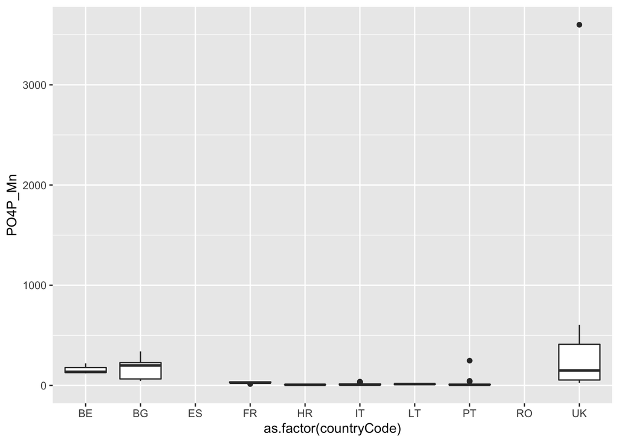

```r
#TW
ggplot(WQdatTWWB_wide, aes(x=as.factor(countryCode),y=PO4P_Mn)) +
  geom_boxplot()
```

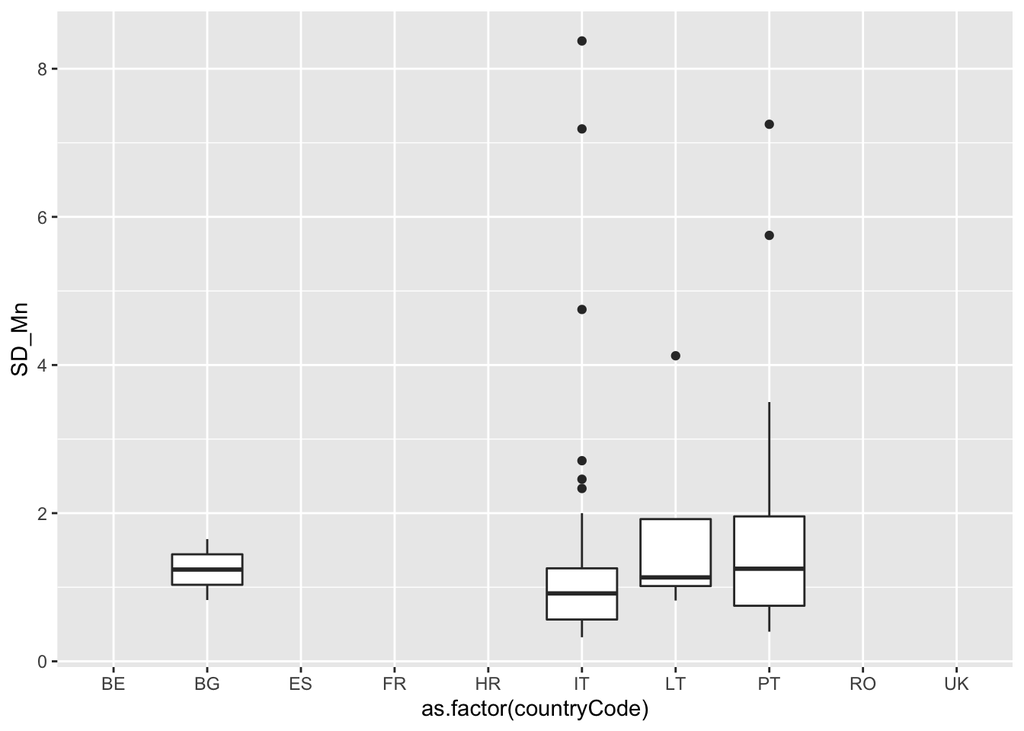

```r
ggplot(WQdatTWWB_wide, aes(x=as.factor(countryCode),y=SD_Mn)) +
  geom_boxplot()
```

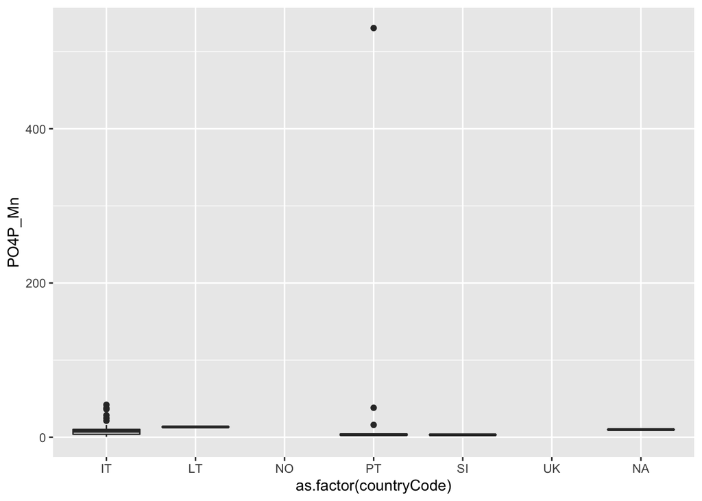

```r
#CW
ggplot(WQdatCWWB_wide, aes(x=as.factor(countryCode),y=PO4P_Mn)) +
  geom_boxplot()
```

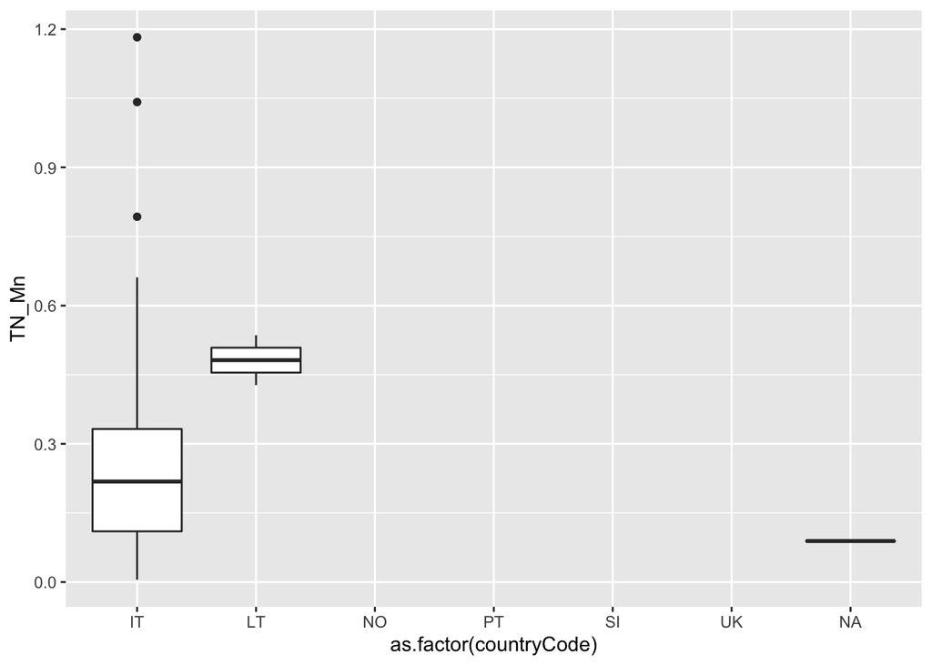

```r
ggplot(WQdatCWWB_wide, aes(x=as.factor(countryCode),y=TN_Mn)) +
  geom_boxplot()
```

### 3. Import BQE data from the WISE4 for TraC Waters Data will be aggregated at Water Body level considering the years (>2009 & <2016) leading to the 2nd reporting cycle 2016

```r
#TW
dat_WFD_TW <- readRDS(here("Data","dat_WFD_TW.rds")) #import biology

dat_WFD_TW_2nd <- dat_WFD_TW %>% #select only 2nd cycle assessments 2016
  filter(cYear==2016) %>%
  filter(StartYear > 2009 |is.na(StartYear)) %>%
  ungroup()

dat_WFD_TW_2nd_wide <- dat_WFD_TW_2nd %>%
  select(euSurfaceWaterBodyCode,countryCode,qeCode,qeStatusOrPotentialValue,naturalAWBHMWB,surfaceWaterBodyTypeCode,
         surfaceWaterBodyIntercalibrationType,surfaceWaterBodyIntercalibrationTypeCode,cArea,cLength) %>%
  pivot_wider(names_from = qeCode, values_from = qeStatusOrPotentialValue)

colnames(dat_WFD_TW_2nd_wide) <- make.names(names(dat_WFD_TW_2nd_wide)) # create valid names

#CW
dat_WFD_CW <- readRDS(here("Data","dat_WFD_CW.rds")) #import biology

dat_WFD_CW_2nd <- dat_WFD_CW %>% #select only 2nd cycle assessments 2016
  filter(cYear==2016) %>%
  filter(StartYear > 2009 |is.na(StartYear)) %>%
  ungroup()

dat_WFD_CW_2nd_wide <- dat_WFD_CW_2nd %>%
  select(euSurfaceWaterBodyCode,countryCode,qeCode,qeStatusOrPotentialValue,naturalAWBHMWB,surfaceWaterBodyTypeCode,
         surfaceWaterBodyIntercalibrationType,surfaceWaterBodyIntercalibrationTypeCode,cArea,cLength) %>%
  pivot_wider(names_from = qeCode, values_from = qeStatusOrPotentialValue)

colnames(dat_WFD_CW_2nd_wide) <- make.names(names(dat_WFD_CW_2nd_wide)) # create valid names
```

### 4. Combine WQ and BQE data for TraC Waters

Data averaged by WB.

```r
#merge Biology and SE for TW
BQESEdatTW_WFD2016 <- inner_join(dat_WFD_TW_2nd_wide,WQdatTWWB_wide, by = c("euSurfaceWaterBodyCode" = "waterBodyIdentifier","countryCode"))

notes <- "2nd cycle (2016) WFD classification (WISE4) linked by WB to WISE6 SoE WQ data (2010-2015) averaged by WB for TW. Created in CombineTraC_SE-BQE.Rmd"
writeLines(notes,here("DataCreated","BQESEdatTW_WFD2016_ReadMe.txt"))

#Save determinands used as xlsx workbook
wb <- createWorkbook()
addWorksheet(wb,"data")
addWorksheet(wb, "notes")
writeData(wb,"data",BQESEdatTW_WFD2016,startRow = 1,startCol = 1)
writeData(wb,"notes",notes,startRow = 1,startCol = 1)
saveWorkbook(wb,file =here("DataCreated","BQESEdatTW_WFD2016.xlsx"),overwrite = TRUE)

#merge Biology and SE for CW
BQESEdatCW_WFD2016 <- inner_join(dat_WFD_CW_2nd_wide,WQdatCWWB_wide, by = c("euSurfaceWaterBodyCode" = "waterBodyIdentifier","countryCode"))

notes <- "2nd cycle (2016) WFD classification (WISE4) linked by WB to WISE6 SoE WQ data (2010-2015) averaged by WB for CW. Created in CombineTraC_SE-BQE.Rmd"
writeLines(notes,here("DataCreated","BQESEdatCW_WFD2016_ReadMe.txt"))

#Save determinands used as xlsx workbook
wb <- createWorkbook()
addWorksheet(wb,"data")
addWorksheet(wb, "notes")
writeData(wb,"data",BQESEdatCW_WFD2016,startRow = 1,startCol = 1)
writeData(wb,"notes",notes,startRow = 1,startCol = 1)
saveWorkbook(wb,file =here("DataCreated","BQESEdatCW_WFD2016.xlsx"),overwrite = TRUE)
```